# **Cyclistic BikeShare data reveal bussiness opportunities**

Compute the descriptive statistics from 2013 to 2023 by weekdays.

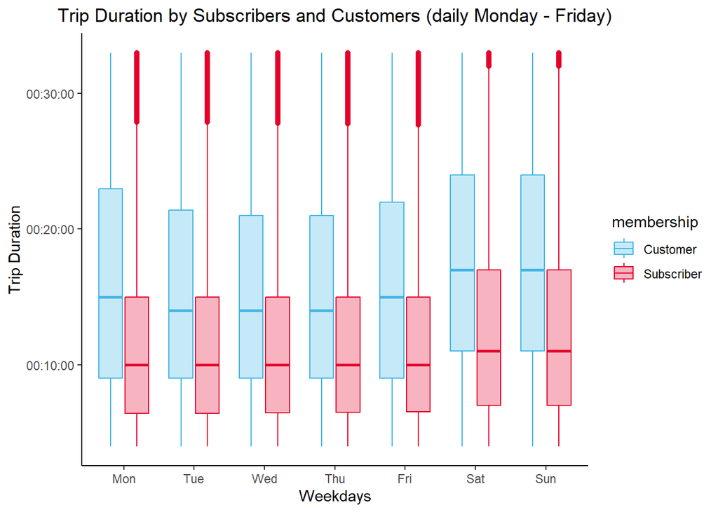

```r
tri_du_wday <- data.frame(
  weekday = c(rep("Mon", 2), rep("Tue", 2), rep("Wed", 2), rep("Thu", 2), rep("Fri", 2), rep("Sat", 2), rep("Sun", 2)),
  membership = c("Subscriber", "Customer"),
  max_duration = c(seconds_to_period(max(ride_data$trip_duration[ride_data$membership == "Subscriber" & ride_data$start_day == "Mon"])),
                   seconds_to_period(max(ride_data$trip_duration[ride_data$membership == "Customer" & ride_data$start_day == "Mon"])),
                   seconds_to_period(max(ride_data$trip_duration[ride_data$membership == "Subscriber" & ride_data$start_day == "Tue"])),
                   seconds_to_period(max(ride_data$trip_duration[ride_data$membership == "Customer" & ride_data$start_day == "Tue"])),
                   seconds_to_period(max(ride_data$trip_duration[ride_data$membership == "Subscriber" & ride_data$start_day == "Wed"])),
                   seconds_to_period(max(ride_data$trip_duration[ride_data$membership == "Customer" & ride_data$start_day == "Wed"])),
                   seconds_to_period(max(ride_data$trip_duration[ride_data$membership == "Subscriber" & ride_data$start_day == "Thu"])),
                   seconds_to_period(max(ride_data$trip_duration[ride_data$membership == "Customer" & ride_data$start_day == "Thu"])),
                   seconds_to_period(max(ride_data$trip_duration[ride_data$membership == "Subscriber" & ride_data$start_day == "Fri"])),
                   seconds_to_period(max(ride_data$trip_duration[ride_data$membership == "Customer" & ride_data$start_day == "Fri"])),
                   seconds_to_period(max(ride_data$trip_duration[ride_data$membership == "Subscriber" & ride_data$start_day == "Sat"])),
                   seconds_to_period(max(ride_data$trip_duration[ride_data$membership == "Customer" & ride_data$start_day == "Sat"])),
                   seconds_to_period(max(ride_data$trip_duration[ride_data$membership == "Subscriber" & ride_data$start_day == "Sun"])),
                   seconds_to_period(max(ride_data$trip_duration[ride_data$membership == "Customer" & ride_data$start_day == "Sun"]))),

  min_duration = c(seconds_to_period(min(ride_data$trip_duration[ride_data$membership == "Subscriber" & ride_data$start_day == "Mon"])),
                   seconds_to_period(min(ride_data$trip_duration[ride_data$membership == "Customer" & ride_data$start_day == "Mon"])),
                   seconds_to_period(min(ride_data$trip_duration[ride_data$membership == "Subscriber" & ride_data$start_day == "Tue"])),
                   seconds_to_period(min(ride_data$trip_duration[ride_data$membership == "Customer" & ride_data$start_day == "Tue"])),
                   seconds_to_period(min(ride_data$trip_duration[ride_data$membership == "Subscriber" & ride_data$start_day == "Wed"])),
                   seconds_to_period(min(ride_data$trip_duration[ride_data$membership == "Customer" & ride_data$start_day == "Wed"])),
                   seconds_to_period(min(ride_data$trip_duration[ride_data$membership == "Subscriber" & ride_data$start_day == "Thu"])),
                   seconds_to_period(min(ride_data$trip_duration[ride_data$membership == "Customer" & ride_data$start_day == "Thu"])),
                   seconds_to_period(min(ride_data$trip_duration[ride_data$membership == "Subscriber" & ride_data$start_day == "Fri"])),
                   seconds_to_period(min(ride_data$trip_duration[ride_data$membership == "Customer" & ride_data$start_day == "Fri"])),
                   seconds_to_period(min(ride_data$trip_duration[ride_data$membership == "Subscriber" & ride_data$start_day == "Sat"])),
                   seconds_to_period(min(ride_data$trip_duration[ride_data$membership == "Customer" & ride_data$start_day == "Sat"])),
                   seconds_to_period(min(ride_data$trip_duration[ride_data$membership == "Subscriber" & ride_data$start_day == "Sun"])),
                   seconds_to_period(min(ride_data$trip_duration[ride_data$membership == "Customer" & ride_data$start_day == "Sun"]))),

  mean_duration = c(round(seconds_to_period(mean(ride_data$trip_duration[ride_data$membership == "Subscriber" & ride_data$start_day == "Mon"])), digits = 0),
                    round(seconds_to_period(mean(ride_data$trip_duration[ride_data$membership == "Customer" & ride_data$start_day == "Mon"])), digits = 0),
                    round(seconds_to_period(mean(ride_data$trip_duration[ride_data$membership == "Subscriber" & ride_data$start_day == "Tue"])), digits = 0),
                    round(seconds_to_period(mean(ride_data$trip_duration[ride_data$membership == "Customer" & ride_data$start_day == "Tue"])), digits = 0),
                    round(seconds_to_period(mean(ride_data$trip_duration[ride_data$membership == "Subscriber" & ride_data$start_day == "Wed"])), digits = 0),
                    round(seconds_to_period(mean(ride_data$trip_duration[ride_data$membership == "Customer" & ride_data$start_day == "Wed"])), digits = 0),
                    round(seconds_to_period(mean(ride_data$trip_duration[ride_data$membership == "Subscriber" & ride_data$start_day == "Thu"])), digits = 0),
                    round(seconds_to_period(mean(ride_data$trip_duration[ride_data$membership == "Customer" & ride_data$start_day == "Thu"])), digits = 0),
                    round(seconds_to_period(mean(ride_data$trip_duration[ride_data$membership == "Subscriber" & ride_data$start_day == "Fri"])), digits = 0),
                    round(seconds_to_period(mean(ride_data$trip_duration[ride_data$membership == "Customer" & ride_data$start_day == "Fri"])), digits = 0),
                    round(seconds_to_period(mean(ride_data$trip_duration[ride_data$membership == "Subscriber" & ride_data$start_day == "Sat"])), digits = 0),
                    round(seconds_to_period(mean(ride_data$trip_duration[ride_data$membership == "Customer" & ride_data$start_day == "Sat"])), digits = 0),
                    round(seconds_to_period(mean(ride_data$trip_duration[ride_data$membership == "Subscriber" & ride_data$start_day == "Sun"])), digits = 0),
                    round(seconds_to_period(mean(ride_data$trip_duration[ride_data$membership == "Customer" & ride_data$start_day == "Sun"])), digits = 0)),

  median_duration = c(seconds_to_period(median(ride_data$trip_duration[ride_data$membership == "Subscriber" & ride_data$start_day == "Mon"])),
                      seconds_to_period(median(ride_data$trip_duration[ride_data$membership == "Customer" & ride_data$start_day == "Mon"])),
                      seconds_to_period(median(ride_data$trip_duration[ride_data$membership == "Subscriber" & ride_data$start_day == "Tue"])),
                      seconds_to_period(median(ride_data$trip_duration[ride_data$membership == "Customer" & ride_data$start_day == "Tue"])),
                      seconds_to_period(median(ride_data$trip_duration[ride_data$membership == "Subscriber" & ride_data$start_day == "Wed"])),
                      seconds_to_period(median(ride_data$trip_duration[ride_data$membership == "Customer" & ride_data$start_day == "Wed"])),
                      seconds_to_period(median(ride_data$trip_duration[ride_data$membership == "Subscriber" & ride_data$start_day == "Thu"])),
                      seconds_to_period(median(ride_data$trip_duration[ride_data$membership == "Customer" & ride_data$start_day == "Thu"])),
                      seconds_to_period(median(ride_data$trip_duration[ride_data$membership == "Subscriber" & ride_data$start_day == "Fri"])),
                      seconds_to_period(median(ride_data$trip_duration[ride_data$membership == "Customer" & ride_data$start_day == "Fri"])),
                      seconds_to_period(median(ride_data$trip_duration[ride_data$membership == "Subscriber" & ride_data$start_day == "Sat"])),
                      seconds_to_period(median(ride_data$trip_duration[ride_data$membership == "Customer" & ride_data$start_day == "Sat"])),
                      seconds_to_period(median(ride_data$trip_duration[ride_data$membership == "Subscriber" & ride_data$start_day == "Sun"])),
                      seconds_to_period(median(ride_data$trip_duration[ride_data$membership == "Customer" & ride_data$start_day == "Sun"]))),

  standard_deviantion = c(sd(ride_data$trip_duration[ride_data$membership == "Subscriber" & ride_data$start_day == "Mon"]),
                          sd(ride_data$trip_duration[ride_data$membership == "Customer" & ride_data$start_day == "Mon"]),
                          sd(ride_data$trip_duration[ride_data$membership == "Subscriber" & ride_data$start_day == "Tue"]),
                          sd(ride_data$trip_duration[ride_data$membership == "Customer" & ride_data$start_day == "Tue"]),
                          sd(ride_data$trip_duration[ride_data$membership == "Subscriber" & ride_data$start_day == "Wed"]),
                          sd(ride_data$trip_duration[ride_data$membership == "Customer" & ride_data$start_day == "Wed"]),
                          sd(ride_data$trip_duration[ride_data$membership == "Subscriber" & ride_data$start_day == "Thu"]),
                          sd(ride_data$trip_duration[ride_data$membership == "Customer" & ride_data$start_day == "Thu"]),
                          sd(ride_data$trip_duration[ride_data$membership == "Subscriber" & ride_data$start_day == "Fri"]),
                          sd(ride_data$trip_duration[ride_data$membership == "Customer" & ride_data$start_day == "Fri"]),
                          sd(ride_data$trip_duration[ride_data$membership == "Subscriber" & ride_data$start_day == "Sat"]),
                          sd(ride_data$trip_duration[ride_data$membership == "Customer" & ride_data$start_day == "Sat"]),
                          sd(ride_data$trip_duration[ride_data$membership == "Subscriber" & ride_data$start_day == "Sun"]),
                          sd(ride_data$trip_duration[ride_data$membership == "Customer" & ride_data$start_day == "Sun"]))
)
kable(tri_du_wday, style = "rmarkdown")

# visualise
# create a box plot.
p_tri_du_wday_box <- ggplot(ride_data, aes(x =  factor(start_day,
                                                       level = c("Mon", "Tue", "Wed", "Thu", "Fri", "Sat", "Sun")),
                                           y = trip_duration, colour = membership, fill = membership)) +
  geom_boxplot(stat = "boxplot", alpha = 0.3) +
  scale_y_time(limits = quantile(ride_data$trip_duration, c(0.1, 0.9))) +
  xlab("Weekdays") +
  ylab("Trip Duration") +
  ggtitle("Trip Duration by Subscribers and Customers (daily Monday - Friday)") +
  scale_colour_manual(name = "membership", values = c("#41B6E6", "#E4002B")) +
  scale_fill_manual(name = "membership", values = c("#41B6E6", "#E4002B")) +
  theme_classic() +
  theme(plot.title = element_text(hjust = 0.5))
p_tri_du_wday_box
```

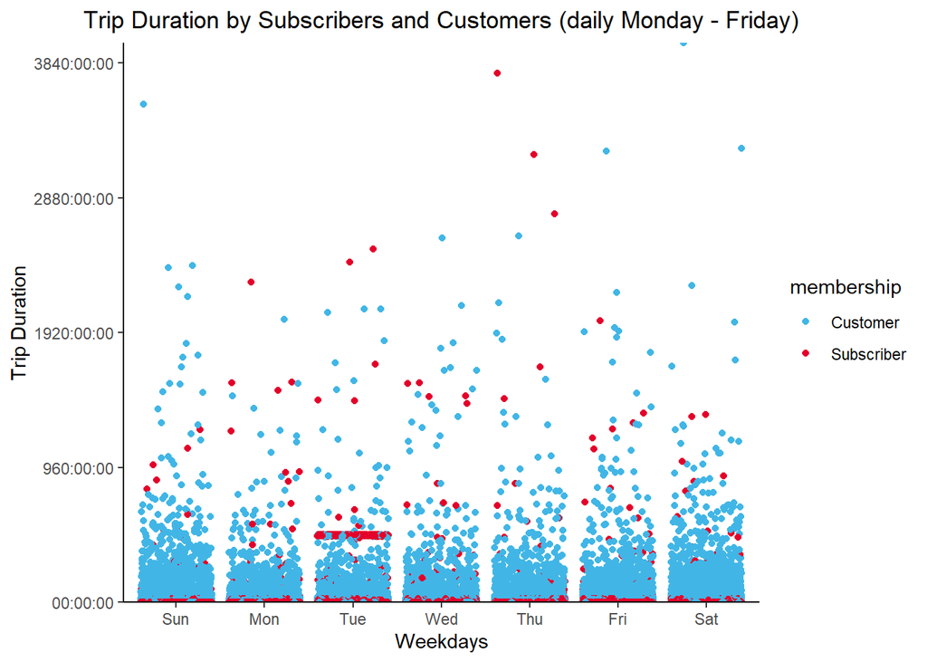

```r
invisible(gc())
# subscribers consistently have shorter mean trip duration than customers.

# scatter points to visualise the entire data set.
ride_data$membership <- as.factor(ride_data$membership)
p_tri_du_point_wday <- ggplot(ride_data, aes(x =  start_day, y = trip_duration, colour = membership)) +
  geom_jitter() +
  scale_y_time(expand = c(0, 0), limits = c(0, NA)) +
  xlab("Weekdays") +
  ylab("Trip Duration") +
  ggtitle("Trip Duration by Subscribers and Customers (daily Monday - Friday)") +
  scale_colour_manual(name = "membership", values = c("#41B6E6", "#E4002B")) +
  theme_classic() +
  theme(plot.title = element_text(hjust = 0.5))
p_tri_du_point_wday
```

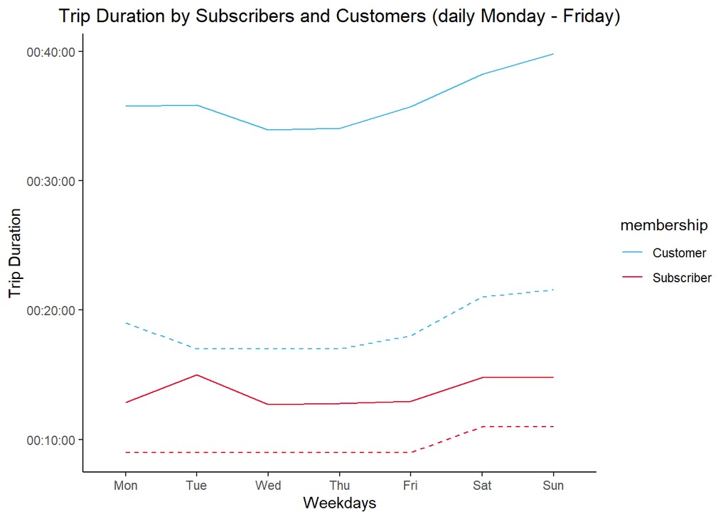

```r
invisible(gc())

# create a line plot to see fluctuation of means during a given week explicitly.
p_tri_du_line_wday <- ggplot(data = tri_du_wday) +
  geom_line(aes(x = factor(weekday,
                           level = c("Mon", "Tue", "Wed", "Thu", "Fri", "Sat", "Sun")),
                y = mean_duration, group = membership, color = membership)) +
  geom_line(linetype = "dashed", aes(x = factor(weekday,
                           level = c("Mon", "Tue", "Wed", "Thu", "Fri", "Sat", "Sun")),
                y = median_duration, group = membership, color = membership)) +
  xlab("Weekdays") +
  ylab("Trip Duration") +
  ggtitle("Trip Duration by Subscribers and Customers (daily Monday - Friday)") +
  scale_colour_manual(name = "membership", values = c("#41B6E6", "#E4002B")) +
  scale_y_time() +
  theme_classic() +
  theme(plot.title = element_text(hjust = 0.5))
p_tri_du_line_wday
```

```r
invisible(gc())
```

[output not shown]

Result of this section: (1) both mean and median trip duration are shorter by subscribers than customers. (2) trip duration is consistently increased on weekends for both subscribers and customers. (3) although Tuesday has a increase in mean trip duration for subscriber, the median stays on the same level as the rest of week day. Accordingly, the deviated mean trip duration for subscribers on Tuesday is likely a result of the large range of trip duration in this data set.

Using statistic tests to examine whether the observed differences among the weekdays are significant.

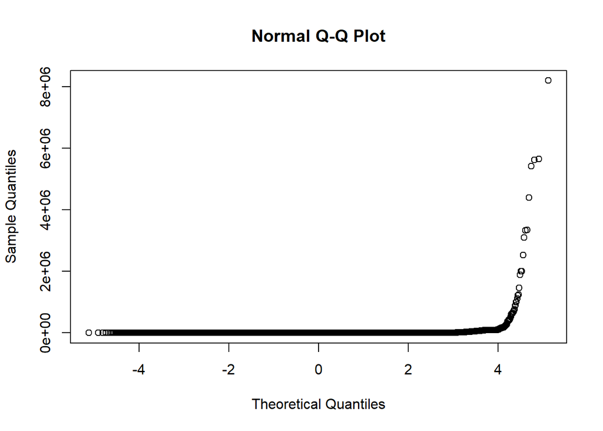

```r
# examine the data to see whether they are normally distributed.
qqnorm(ride_data$trip_duration[ride_data$membership == "Subscriber" & ride_data$start_day ==
    "Mon"])
```

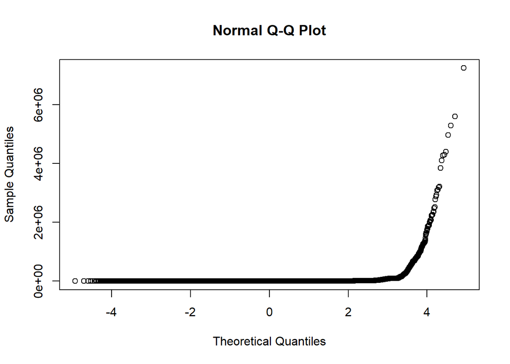

```r
# not normal
qqnorm(ride_data$trip_duration[ride_data$membership == "Customer" & ride_data$start_day ==
    "Mon"])
```

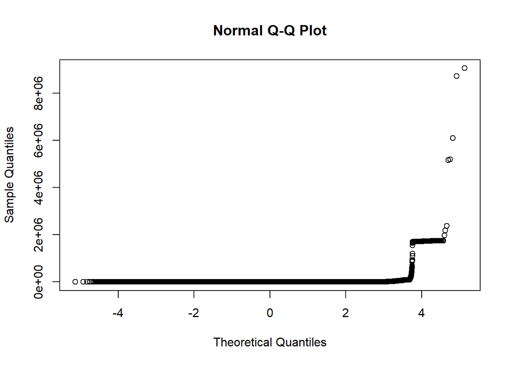

```r
# not normal
qqnorm(ride_data$trip_duration[ride_data$membership == "Subscriber" & ride_data$start_day ==
    "Tue"])
```

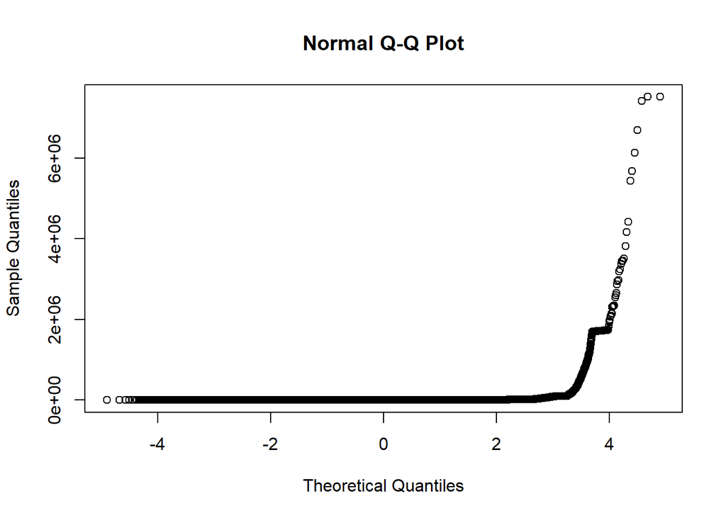

```r
# not normal
qqnorm(ride_data$trip_duration[ride_data$membership == "Customer" & ride_data$start_day ==
    "Tue"])
```

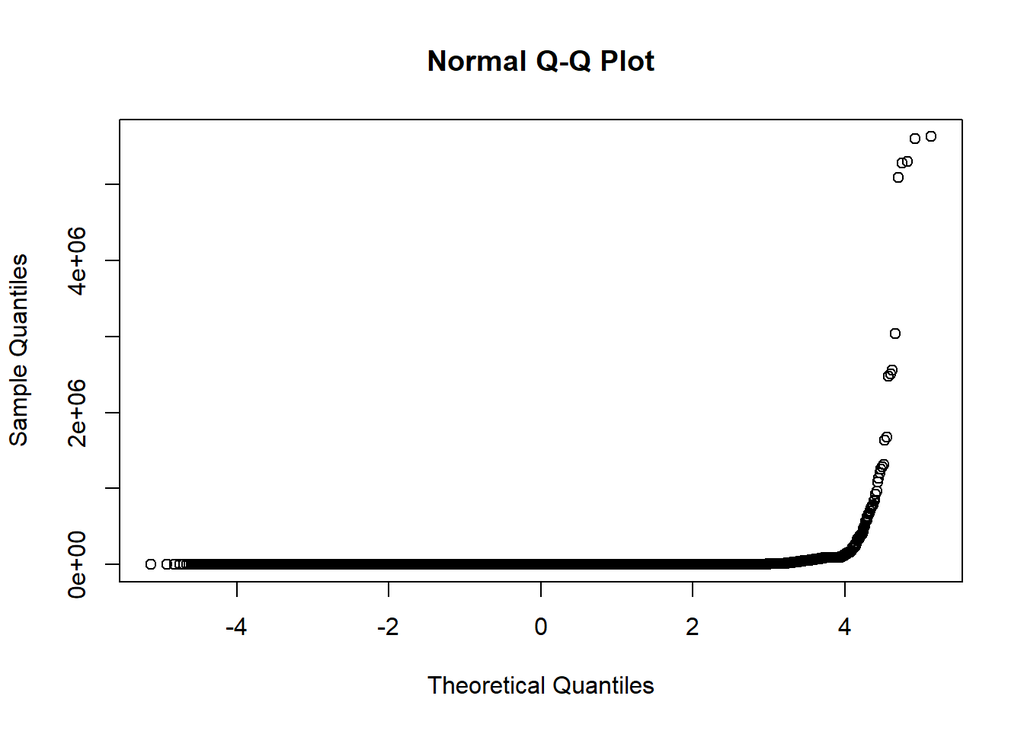

```r
# not normal
qqnorm(ride_data$trip_duration[ride_data$membership == "Subscriber" & ride_data$start_day ==
    "Wed"])
```

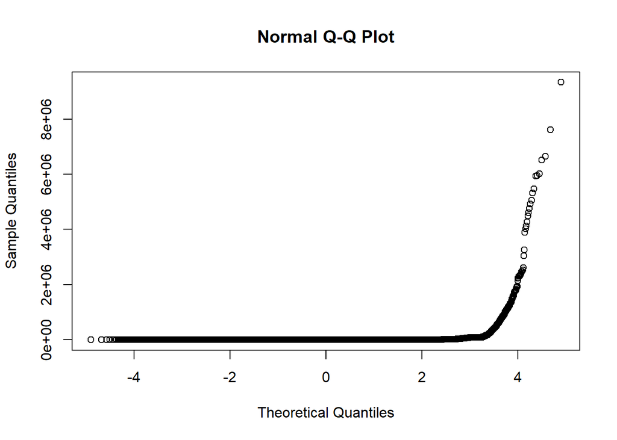

```r
# not normal
qqnorm(ride_data$trip_duration[ride_data$membership == "Customer" & ride_data$start_day ==
    "Wed"])
```

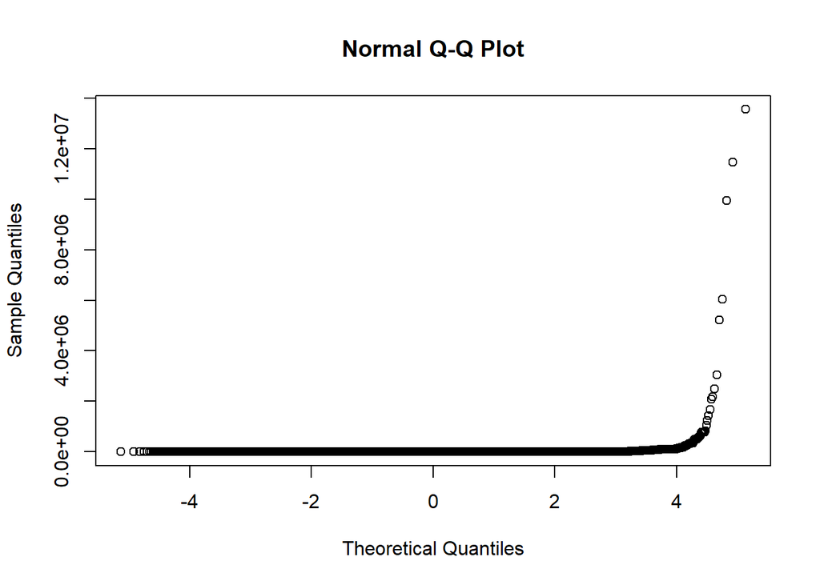

```r
# not normal
qqnorm(ride_data$trip_duration[ride_data$membership == "Subscriber" & ride_data$start_day ==
    "Thu"])
```

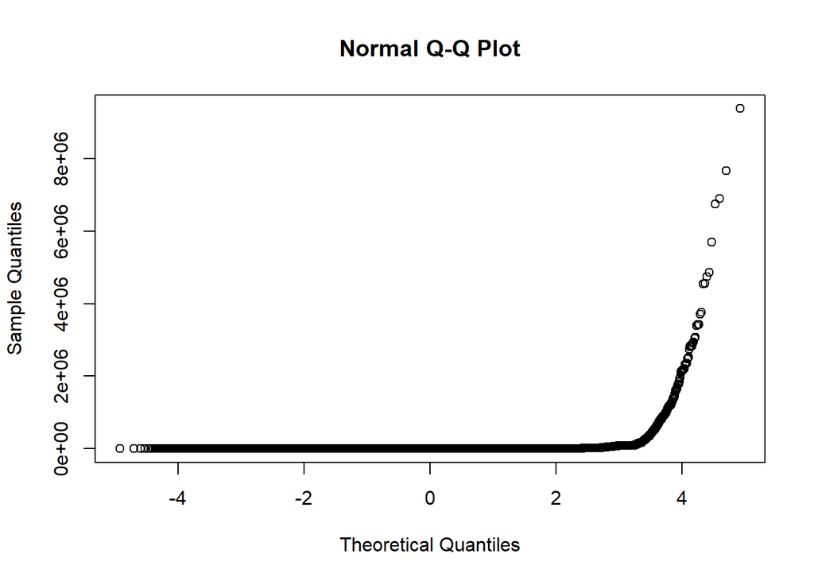

```r
# not normal
qqnorm(ride_data$trip_duration[ride_data$membership == "Customer" & ride_data$start_day ==
    "Thu"])
```

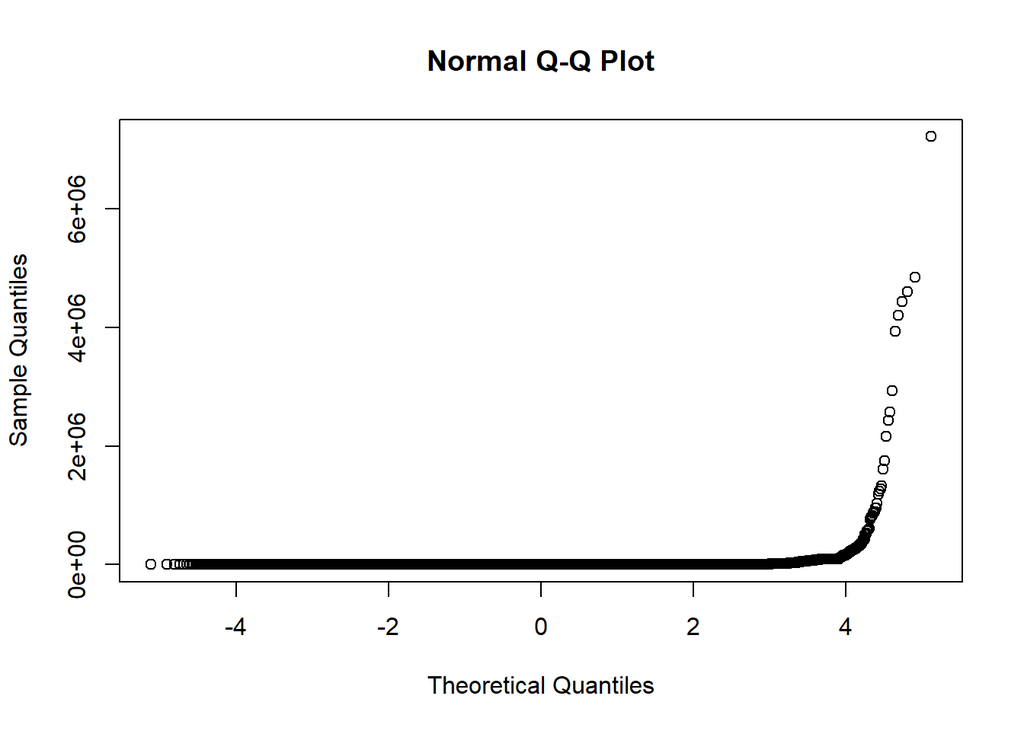

```r
# not normal
qqnorm(ride_data$trip_duration[ride_data$membership == "Subscriber" & ride_data$start_day ==
    "Fri"])
```

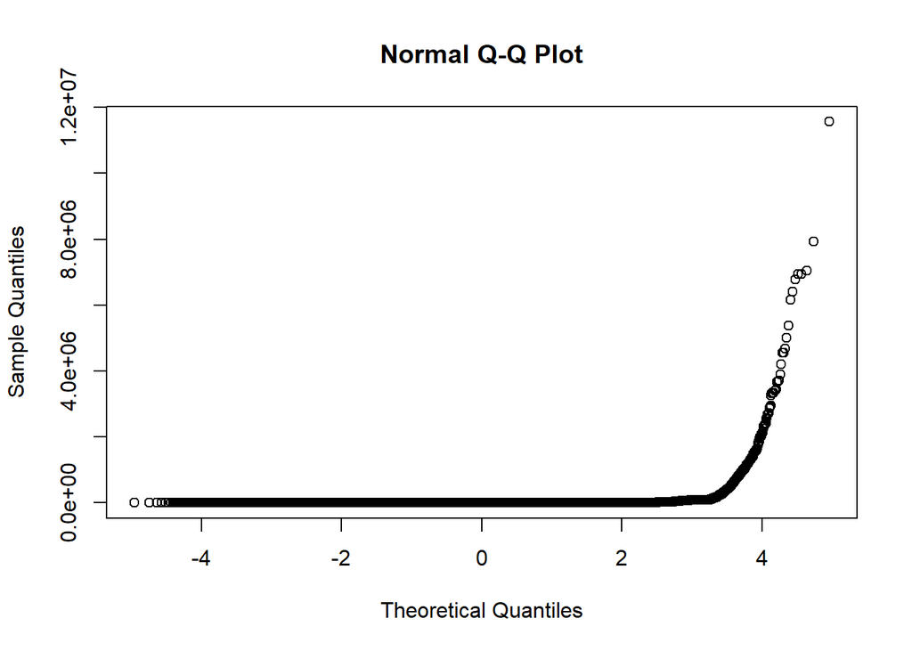

```r
# not normal
qqnorm(ride_data$trip_duration[ride_data$membership == "Customer" & ride_data$start_day ==
    "Fri"])
```

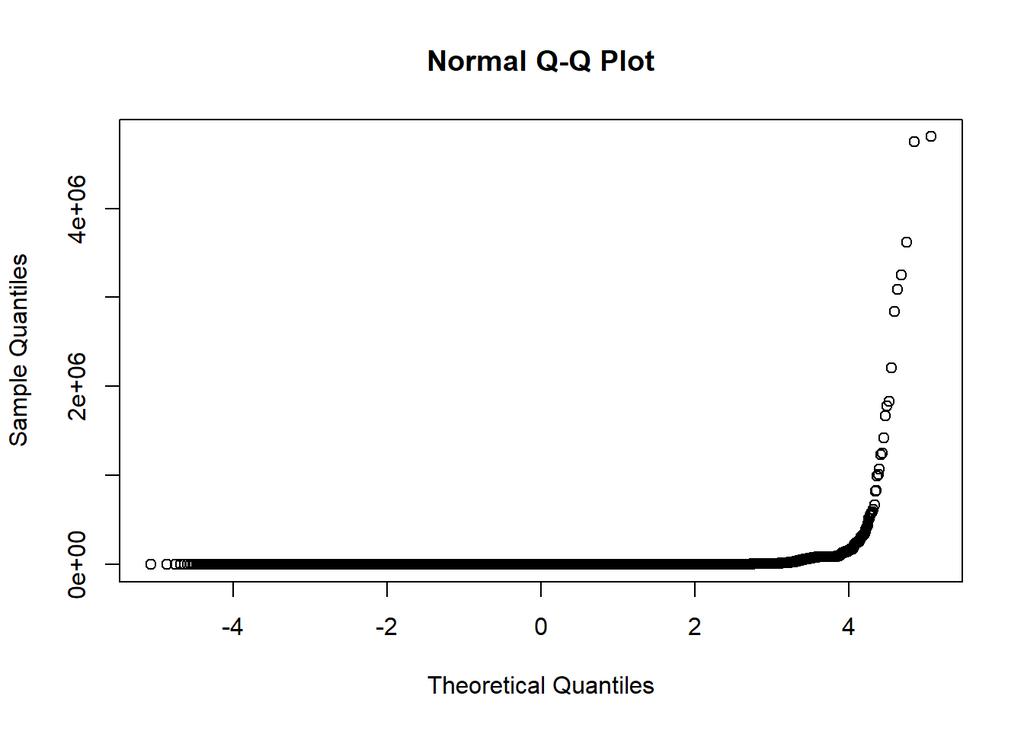

```r
# not normal
qqnorm(ride_data$trip_duration[ride_data$membership == "Subscriber" & ride_data$start_day ==
    "Sat"])
```

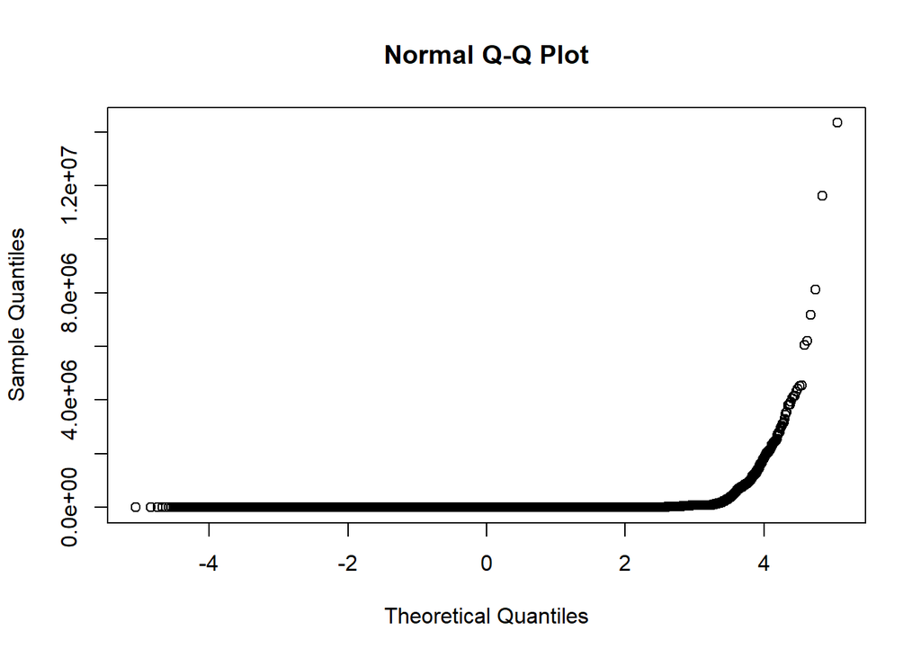

```r
# not normal
qqnorm(ride_data$trip_duration[ride_data$membership == "Customer" & ride_data$start_day ==
    "Sat"])
```